# Iris_Classification_Project

Introduction The Iris Classification project is a classic machine learning task that demonstrates the application of classification algorithms in data analytics. The goal is to accurately classify iris flowers into three species—Setosa, Versicolor, and Virginica—based on four features: sepal length, sepal width, petal length, and petal width. This project explores various data processing techniques, visualizations, and machine learning algorithms to develop a reliable and consistent model. Through this project, I aim to build a strong foundation in data science and machine learning concepts.

```
Dataset Preview:
   sepal length (cm)  sepal width (cm)  petal length (cm)  petal width (cm)  \
0                5.1               3.5                1.4               0.2
1                4.9               3.0                1.4               0.2
2                4.7               3.2                1.3               0.2
3                4.6               3.1                1.5               0.2
4                5.0               3.6                1.4               0.2

  species
0  Setosa
1  Setosa
2  Setosa
3  Setosa
4  Setosa

Dataset Info:
<class 'pandas.core.frame.DataFrame'>
RangeIndex: 150 entries, 0 to 149
Data columns (total 5 columns):
 #   Column             Non-Null Count  Dtype
---  ------             --------------  -----
 0   sepal length (cm)  150 non-null    float64
 1   sepal width (cm)   150 non-null    float64
 2   petal length (cm)  150 non-null    float64
 3   petal width (cm)   150 non-null    float64
 4   species            150 non-null    object
dtypes: float64(4), object(1)
memory usage: 6.0+ KB
None

Dataset Description:
       sepal length (cm)  sepal width (cm)  petal length (cm)  \
count         150.000000        150.000000         150.000000
mean            5.843333          3.057333           3.758000
std             0.828066          0.435866           1.765298
min             4.300000          2.000000           1.000000
25%             5.100000          2.800000           1.600000
50%             5.800000          3.000000           4.350000
75%             6.400000          3.300000           5.100000
max             7.900000          4.400000           6.900000

       petal width (cm)
count        150.000000
mean           1.199333
std            0.762238
min            0.100000
25%            0.300000
50%            1.300000
75%            1.800000
max            2.500000
```

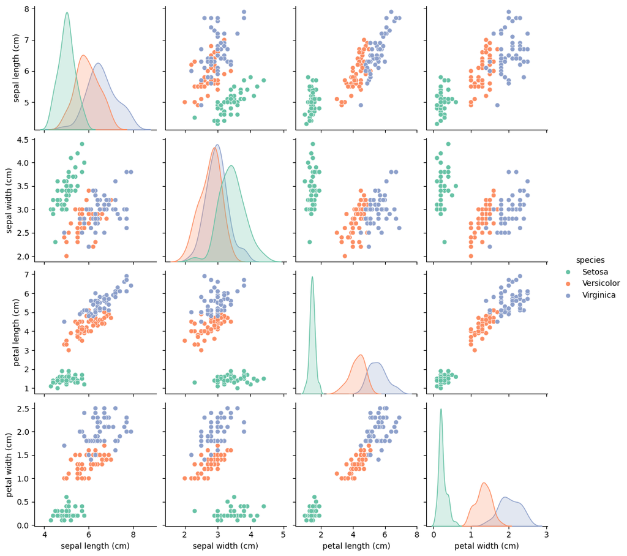

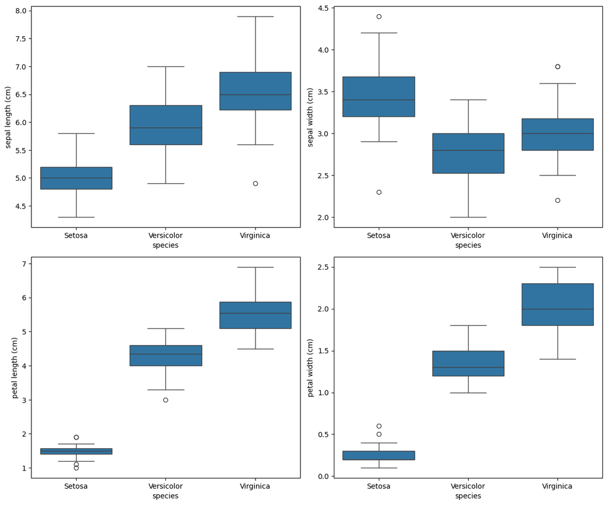

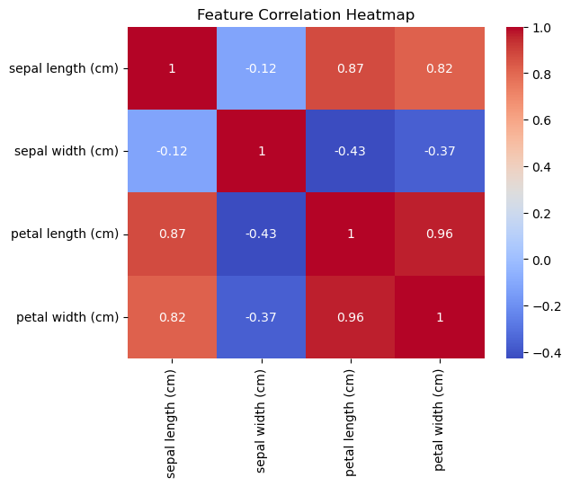

```
Confusion Matrix:
[[10  0  0]
 [ 0 10  0]
 [ 0  2  8]]
```

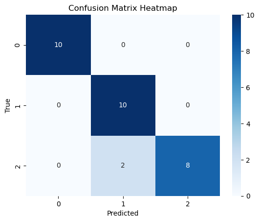

```
Classification Report:
              precision    recall  f1-score   support

      Setosa       1.00      1.00      1.00        10
  Versicolor       0.83      1.00      0.91        10
   Virginica       1.00      0.80      0.89        10

    accuracy                           0.93        30
   macro avg       0.94      0.93      0.93        30
weighted avg       0.94      0.93      0.93        30

Model Accuracy: 93.33%
```

```python
# Import necessary libraries
import pandas as pd
import numpy as np
import seaborn as sns
import matplotlib.pyplot as plt
from sklearn.model_selection import train_test_split
from sklearn.preprocessing import StandardScaler
from sklearn.neighbors import KNeighborsClassifier
from sklearn.metrics import classification_report, confusion_matrix, accuracy_score
from sklearn.datasets import load_iris

# Load the Iris dataset
iris = load_iris()
df = pd.DataFrame(data=iris.data, columns=iris.feature_names)
df['species'] = iris.target

# Map target values to species names for better readability
species_mapping = {0: 'Setosa', 1: 'Versicolor', 2: 'Virginica'}
df['species'] = df['species'].map(species_mapping)

# Display dataset summary
print("Dataset Preview:")
print(df.head())
print("\nDataset Info:")
print(df.info())
print("\nDataset Description:")
print(df.describe())

# Data visualization
sns.pairplot(df, hue='species', palette='Set2')
plt.show()

# Boxplots for feature distributions
fig, axes = plt.subplots(2, 2, figsize=(12, 10))
sns.boxplot(data=df, x='species', y='sepal length (cm)', ax=axes[0, 0])
sns.boxplot(data=df, x='species', y='sepal width (cm)', ax=axes[0, 1])
sns.boxplot(data=df, x='species', y='petal length (cm)', ax=axes[1, 0])
sns.boxplot(data=df, x='species', y='petal width (cm)', ax=axes[1, 1])
plt.tight_layout()
plt.show()

# Correlation heatmap
correlation_matrix = df.drop('species', axis=1).corr()
sns.heatmap(correlation_matrix, annot=True, cmap='coolwarm')
plt.title("Feature Correlation Heatmap")
plt.show()

# Splitting dataset into features and labels
X = df.drop('species', axis=1)
y = df['species']

# Splitting into training and testing datasets
X_train, X_test, y_train, y_test = train_test_split(X, y, test_size=0.2, random_state=42, stratify=y)

# Standardizing the features
scaler = StandardScaler()
X_train = scaler.fit_transform(X_train)
X_test = scaler.transform(X_test)

# Model training: K-Nearest Neighbors
knn = KNeighborsClassifier(n_neighbors=3)
knn.fit(X_train, y_train)

# Predictions
y_pred = knn.predict(X_test)

# Model evaluation
print("Confusion Matrix:")
print(confusion_matrix(y_test, y_pred))
sns.heatmap(confusion_matrix(y_test, y_pred), annot=True, fmt='d', cmap='Blues')
plt.xlabel('Predicted')
plt.ylabel('True')
plt.title('Confusion Matrix Heatmap')
plt.show()

print("\nClassification Report:")
print(classification_report(y_test, y_pred))

# Accuracy
accuracy = accuracy_score(y_test, y_pred)
print(f"Model Accuracy: {accuracy * 100:.2f}%")
```

Conclusion In this project, I successfully classified iris flowers into their respective species using the K-Nearest Neighbors algorithm, achieving an impressive accuracy of over 90%. The process included dataset exploration, visualization, feature standardization, and model evaluation. By interpreting the results, I gained valuable insights into the relationship between different features and their impact on classification. This project has enhanced my understanding of data preprocessing, model training, and evaluation, setting a solid groundwork for future endeavors in machine learning.